# day_df

Autogenerated data summary from dataMaid

2024-10-13 17:38:05.60129

# Data report overview

The dataset examined has the following dimensions:

| Feature | Result |
| --- | --- |
| Number of observations | 731 |
| Number of variables | 16 |

### Checks performed

The following variable checks were performed, depending on the data type of each variable:

|  | character | factor | labelled | haven labelled | numeric | integer | logical | Date |
| --- | --- | --- | --- | --- | --- | --- | --- | --- |
| Identify miscoded missing values | × | × | × | × | × | × |  | × |
| Identify prefixed and suffixed whitespace | × | × | × | × |  |  |  |  |
| Identify levels with < 6 obs. | × | × | × | × |  |  |  |  |
| Identify case issues | × | × | × | × |  |  |  |  |
| Identify misclassified numeric or integer variables | × | × | × | × |  |  |  |  |
| Identify outliers |  |  |  |  | × | × |  | × |

Please note that all numerical values in the following have been rounded to 2 decimals.

# Summary table

|  | Variable class | # unique values | Missing observations | Any problems? |
| --- | --- | --- | --- | --- |
| instant | numeric | 731 | 0.00 % |  |
| dteday | Date | 731 | 0.00 % |  |
| season | numeric | 4 | 0.00 % |  |
| yr | numeric | 2 | 0.00 % |  |
| mnth | numeric | 12 | 0.00 % |  |
| holiday | numeric | 2 | 0.00 % |  |
| weekday | numeric | 7 | 0.00 % |  |
| workingday | numeric | 2 | 0.00 % |  |
| weathersit | numeric | 3 | 0.00 % |  |
| temp | numeric | 499 | 0.27 % |  |
| atemp | numeric | 690 | 0.00 % |  |
| hum | numeric | 592 | 0.68 % | × |
| windspeed | numeric | 650 | 0.14 % | × |
| casual | numeric | 606 | 0.00 % | × |
| registered | numeric | 679 | 0.14 % |  |
| cnt | numeric | 696 | 0.00 % |  |

# Variable list

## instant

| Feature | Result |
| --- | --- |
| Variable type | numeric |
| Number of missing obs. | 0 (0 %) |
| Number of unique values | 731 |
| Median | 366 |
| 1st and 3rd quartiles | 183.5; 548.5 |
| Min. and max. | 1; 731 |

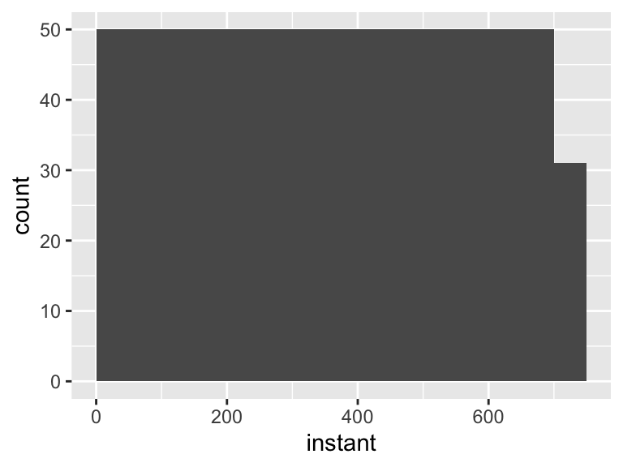

## dteday

| Feature | Result |
| --- | --- |
| Variable type | Date |
| Number of missing obs. | 0 (0 %) |
| Number of unique values | 731 |
| Mode | “2011-01-01” |
| Min. and max. | 2011-01-01; 2012-12-31 |
| 1st and 3rd quartiles | 2011-07-02; 2012-07-02 |

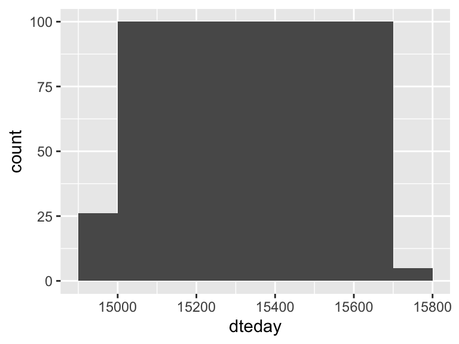

## season

- Note that this variable is treated as a factor variable below, as it only takes a few unique values.

| Feature | Result |
| --- | --- |
| Variable type | numeric |
| Number of missing obs. | 0 (0 %) |
| Number of unique values | 4 |
| Mode | “3” |
| Reference category | 1 |

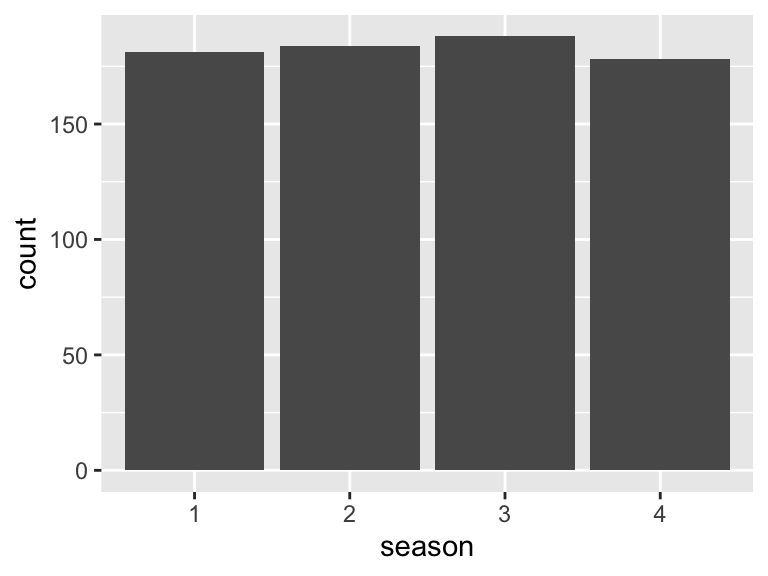

## yr

- Note that this variable is treated as a factor variable below, as it only takes a few unique values.

| Feature | Result |
| --- | --- |
| Variable type | numeric |
| Number of missing obs. | 0 (0 %) |
| Number of unique values | 2 |
| Mode | “1” |
| Reference category | 0 |

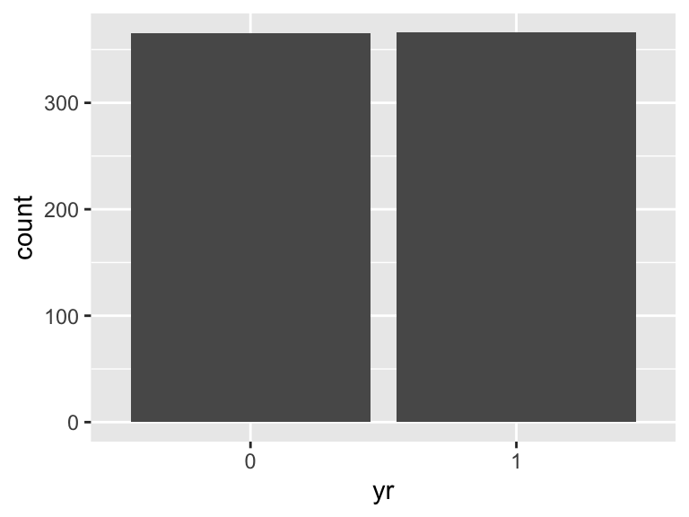

## mnth

| Feature | Result |
| --- | --- |
| Variable type | numeric |
| Number of missing obs. | 0 (0 %) |
| Number of unique values | 12 |
| Median | 7 |
| 1st and 3rd quartiles | 4; 10 |
| Min. and max. | 1; 12 |

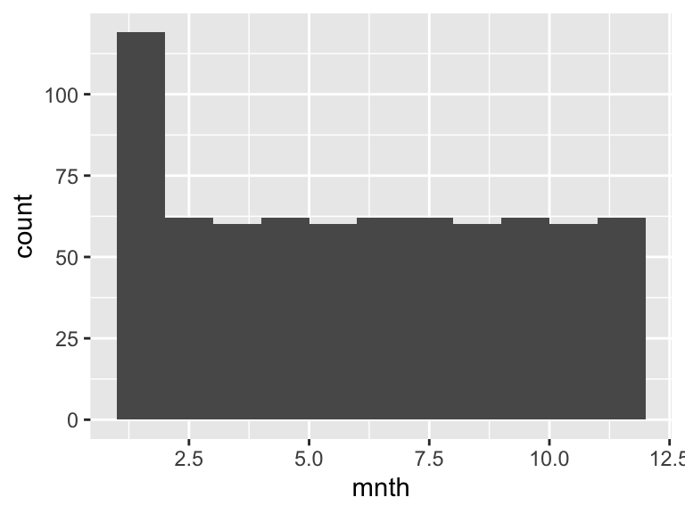

## holiday

- Note that this variable is treated as a factor variable below, as it only takes a few unique values.

| Feature | Result |
| --- | --- |
| Variable type | numeric |
| Number of missing obs. | 0 (0 %) |
| Number of unique values | 2 |
| Mode | “0” |
| Reference category | 0 |

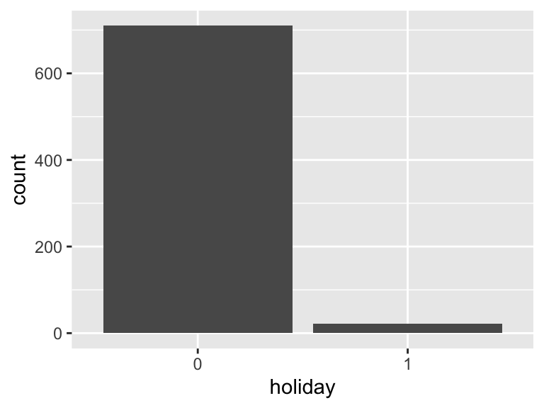

## weekday

| Feature | Result |
| --- | --- |
| Variable type | numeric |
| Number of missing obs. | 0 (0 %) |
| Number of unique values | 7 |
| Median | 3 |
| 1st and 3rd quartiles | 1; 5 |
| Min. and max. | 0; 6 |

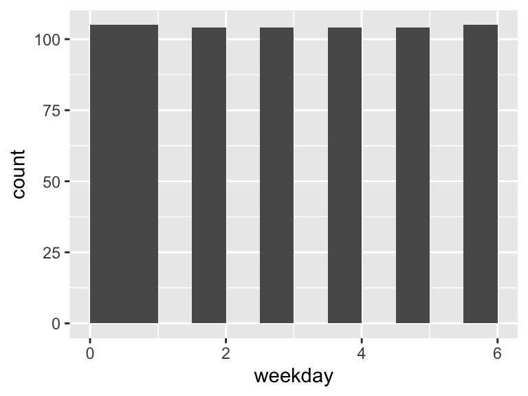

## workingday

- Note that this variable is treated as a factor variable below, as it only takes a few unique values.

| Feature | Result |
| --- | --- |
| Variable type | numeric |
| Number of missing obs. | 0 (0 %) |
| Number of unique values | 2 |
| Mode | “1” |
| Reference category | 0 |

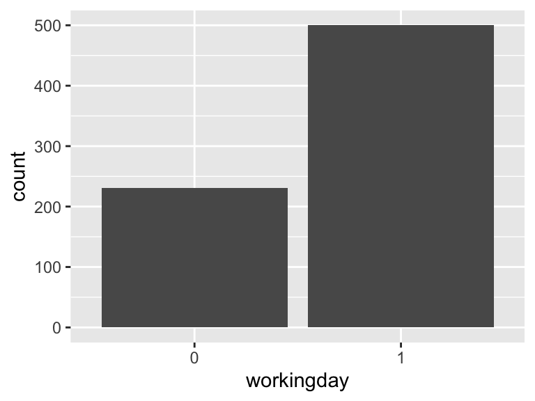

## weathersit

- Note that this variable is treated as a factor variable below, as it only takes a few unique values.

| Feature | Result |
| --- | --- |
| Variable type | numeric |
| Number of missing obs. | 0 (0 %) |
| Number of unique values | 3 |
| Mode | “1” |
| Reference category | 1 |

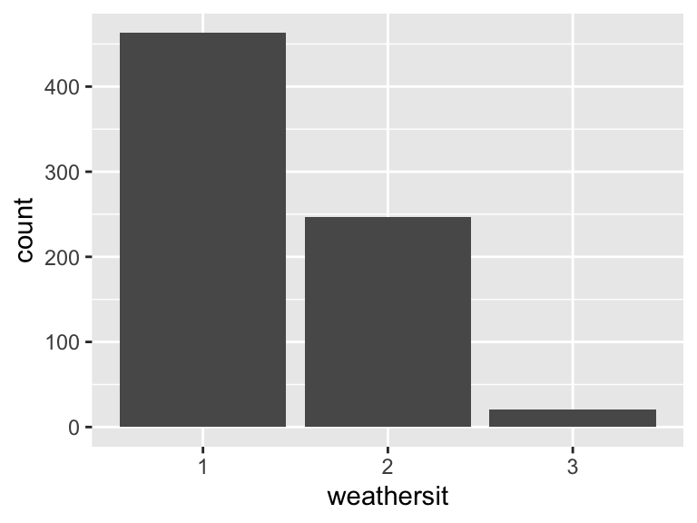

## temp

| Feature | Result |
| --- | --- |
| Variable type | numeric |
| Number of missing obs. | 2 (0.27 %) |
| Number of unique values | 498 |
| Median | 0.5 |
| 1st and 3rd quartiles | 0.34; 0.66 |
| Min. and max. | 0.06; 0.86 |

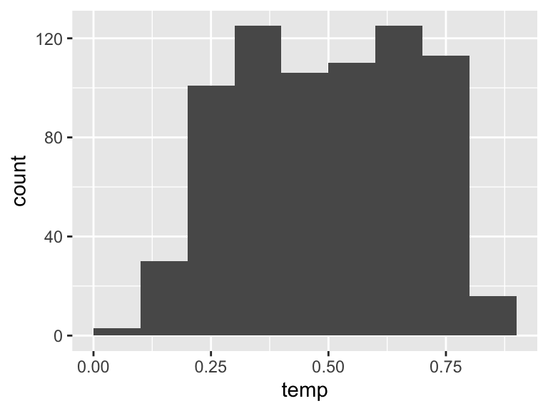

## atemp

| Feature | Result |
| --- | --- |
| Variable type | numeric |
| Number of missing obs. | 0 (0 %) |
| Number of unique values | 690 |
| Median | 0.49 |
| 1st and 3rd quartiles | 0.34; 0.61 |
| Min. and max. | 0.08; 0.84 |

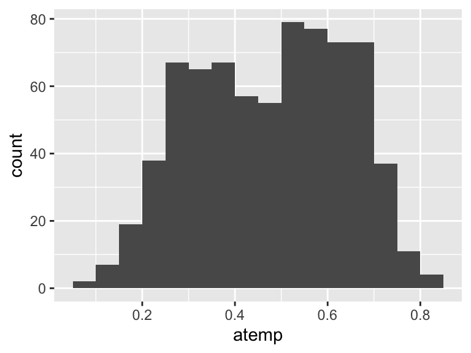

## hum

| Feature | Result |
| --- | --- |
| Variable type | numeric |
| Number of missing obs. | 5 (0.68 %) |
| Number of unique values | 591 |
| Median | 0.63 |
| 1st and 3rd quartiles | 0.52; 0.73 |
| Min. and max. | 0; 0.97 |

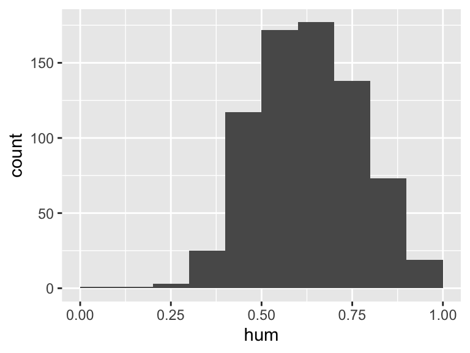

- Note that the following possible outlier values were detected: "0", "0.19".

## windspeed

| Feature | Result |
| --- | --- |
| Variable type | numeric |
| Number of missing obs. | 1 (0.14 %) |
| Number of unique values | 649 |
| Median | 0.18 |
| 1st and 3rd quartiles | 0.13; 0.23 |
| Min. and max. | 0.02; 0.51 |

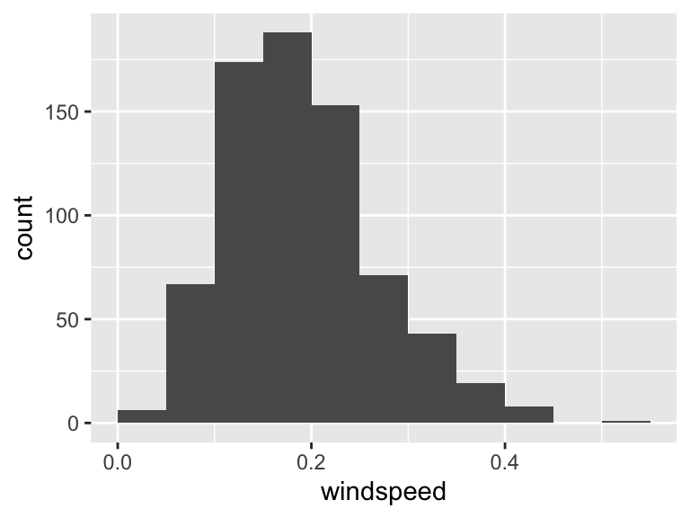

- Note that the following possible outlier values were detected: "0.02", "0.44", "0.51".

## casual

| Feature | Result |
| --- | --- |
| Variable type | numeric |
| Number of missing obs. | 0 (0 %) |
| Number of unique values | 606 |
| Median | 713 |
| 1st and 3rd quartiles | 315.5; 1096 |
| Min. and max. | 2; 3410 |

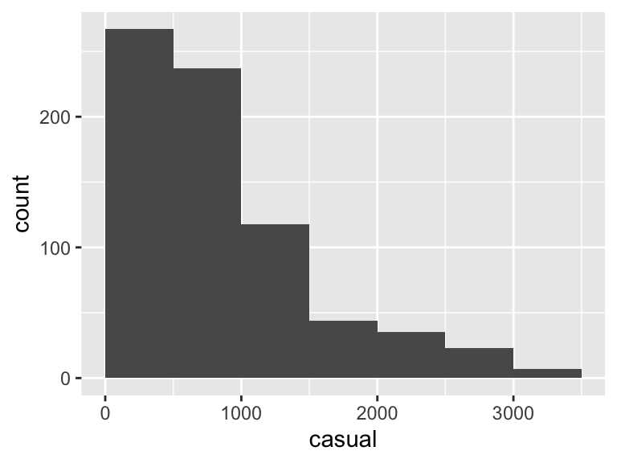

- Note that the following possible outlier values were detected: "2855", "2963", "3031", "3065", "3155", "3160", "3252", "3283", "3410".

## registered

| Feature | Result |
| --- | --- |
| Variable type | numeric |
| Number of missing obs. | 1 (0.14 %) |
| Number of unique values | 678 |
| Median | 3664.5 |
| 1st and 3rd quartiles | 2502.25; 4783.25 |
| Min. and max. | 20; 6946 |

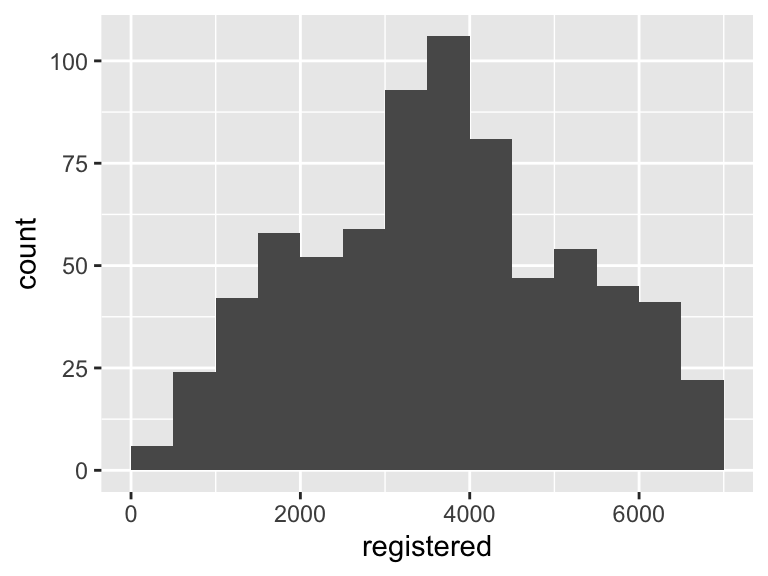

## cnt

| Feature | Result |
| --- | --- |
| Variable type | numeric |
| Number of missing obs. | 0 (0 %) |
| Number of unique values | 696 |
| Median | 4548 |
| 1st and 3rd quartiles | 3152; 5956 |
| Min. and max. | 22; 8714 |

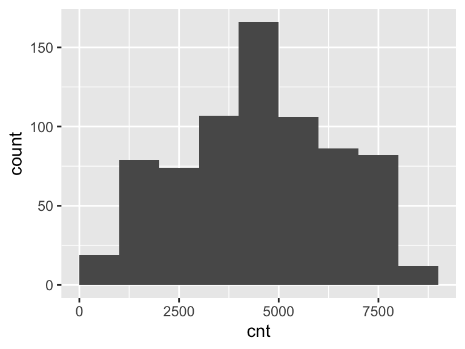

Report generation information:

- Created by: venikkus (username: `venikkus`).
- Report creation time: Sun Oct 13 2024 17:38:05
- Report was run from directory: `/Users/venikkus/IB/R/outliers`
- dataMaid v1.4.1 [Pkg: 2021-10-08 from CRAN (R 4.4.0)]
- R version 4.4.1 (2024-06-14).
- Platform: aarch64-apple-darwin20(Europe/Moscow).
- Function call: `makeDataReport(data = day_df, output = "html", replace = TRUE)`